# MarketingCampaign_MF

#### Is there any pattern between the age of customers and the last campaign acceptance rate?

```python
#Checking Age range to create bins
np.sort(marketing_data_no_outliers['Age'].unique())
```

```
array([28, 29, 30, 31, 32, 33, 34, 35, 36, 37, 38, 39, 40, 41, 42, 43, 44,
       45, 46, 47, 48, 49, 50, 51, 52, 53, 54, 55, 56, 57, 58, 59, 60, 61,
       62, 63, 64, 65, 66, 67, 68, 69, 70, 71, 72, 73, 74, 75, 76, 77, 78,
       79, 80, 81, 83, 84, 92], dtype=int16)
```

```python
# Data Binning: Creating bins for the 'Age' column

# Define bin edges
bin_edges = [0, 39, 59, 79, np.inf]  # Adjust bin edges as needed

# Define bin labels
bin_labels = ['Young Adult', 'Middle Age', 'Senior Citizen', 'Elderly']

# Create a new categorical column 'Age_Category' based on binning
marketing_data_no_outliers['Age_Category'] = pd.cut(marketing_data_no_outliers['Age'], bins=bin_edges, labels=bin_labels, right=False) # right: if rightmost edge is included in next bin or not




# Create aggregated data by age group and campaign acceptance

agg = pd.melt(marketing_data_no_outliers,  id_vars='Age_Category',
                  value_vars=['AcceptedCmp1','AcceptedCmp2','AcceptedCmp3','AcceptedCmp4','AcceptedCmp5', 'Response'],
                       var_name='Campaign', value_name='Accepted')

# Fetching only those customers who accepted the offer
AcceptedOffer = agg[agg['Accepted']==1].drop(columns='Accepted')
AcceptedOffer = pd.DataFrame(AcceptedOffer.groupby(['Age_Category','Campaign']).value_counts()).reset_index()

# Create separate datasets to analyze offer acceptance rate across Campaigns
Campaign1 = AcceptedOffer[AcceptedOffer['Campaign']=='AcceptedCmp1'].drop(columns='Campaign').rename(columns={'count':'No. of Customers'})
Campaign2 = AcceptedOffer[AcceptedOffer['Campaign']=='AcceptedCmp2'].drop(columns='Campaign').rename(columns={'count':'No. of Customers'})
Campaign3 = AcceptedOffer[AcceptedOffer['Campaign']=='AcceptedCmp3'].drop(columns='Campaign').rename(columns={'count':'No. of Customers'})
Campaign4 = AcceptedOffer[AcceptedOffer['Campaign']=='AcceptedCmp4'].drop(columns='Campaign').rename(columns={'count':'No. of Customers'})
Campaign5 = AcceptedOffer[AcceptedOffer['Campaign']=='AcceptedCmp5'].drop(columns='Campaign').rename(columns={'count':'No. of Customers'})
LastCampaign = AcceptedOffer[AcceptedOffer['Campaign']=='Response'].drop(columns='Campaign').rename(columns={'count':'No. of Customers'})

# Create separate datasets to analyze offer acceptance rate across Age groups
YoungAdult = AcceptedOffer[AcceptedOffer['Age_Category']=='Young Adult'].drop(columns='Age_Category').rename(columns={'count':'No. of Customers'})
MiddleAge = AcceptedOffer[AcceptedOffer['Age_Category']=='Middle Age'].drop(columns='Age_Category').rename(columns={'count':'No. of Customers'})
SeniorCitizen = AcceptedOffer[AcceptedOffer['Age_Category']=='Senior Citizen'].drop(columns='Age_Category').rename(columns={'count':'No. of Customers'})
Elderly = AcceptedOffer[AcceptedOffer['Age_Category']=='Elderly'].drop(columns='Age_Category').rename(columns={'count':'No. of Customers'})

# Cleanup Campaign column
YoungAdult['Campaign']=YoungAdult['Campaign'].str.replace('AcceptedCmp','Campaign ').str.replace('Response','Last Campaign')
MiddleAge['Campaign']=MiddleAge['Campaign'].str.replace('AcceptedCmp','Campaign ').str.replace('Response','Last Campaign')
SeniorCitizen['Campaign']=SeniorCitizen['Campaign'].str.replace('AcceptedCmp','Campaign ').str.replace('Response','Last Campaign')
Elderly['Campaign']=Elderly['Campaign'].str.replace('AcceptedCmp','Campaign ').str.replace('Response','Last Campaign')
```

[output not shown]

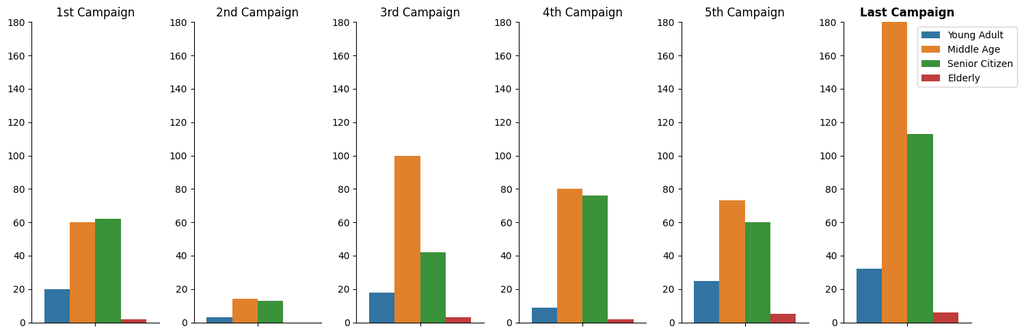

```python
# Plotting charts for campaign acceptances for comparison and detecting patterns (if any)

data=[Campaign1,Campaign2,Campaign3,Campaign4,Campaign5,LastCampaign]
cols=['AcceptedCmp1','AcceptedCmp2','AcceptedCmp3','AcceptedCmp4','AcceptedCmp5','Response']
titles=['1st Campaign','2nd Campaign','3rd Campaign','4th Campaign','5th Campaign','Last Campaign']


fig, axes = plt.subplots(nrows=1, ncols=6, figsize=(15,5))
for i, col in enumerate(cols):
        plot=sns.barplot(data=data[i], y='No. of Customers', hue='Age_Category', ax=axes[i])
        if i<5: axes[i].legend_.remove()
        plt.legend(loc='upper right', bbox_to_anchor=(1.4,1))
        sns.despine(top=True, right=True)
        axes[i].set_xlabel('' )
        axes[i].set_ylabel('')
        if i<5:axes[i].set_title(titles[i])
        else: axes[i].set_title(titles[i], fontweight='bold')
        axes[i].set_xticklabels(axes[i].get_xticklabels(), rotation=45)
        plot.set_ylim(0, 180)

plt.tight_layout()
plt.show()
```

*Insights*

Conversely, we try to guage the pattern of Campaign Acceptance rate among individual age groups.

[output not shown]

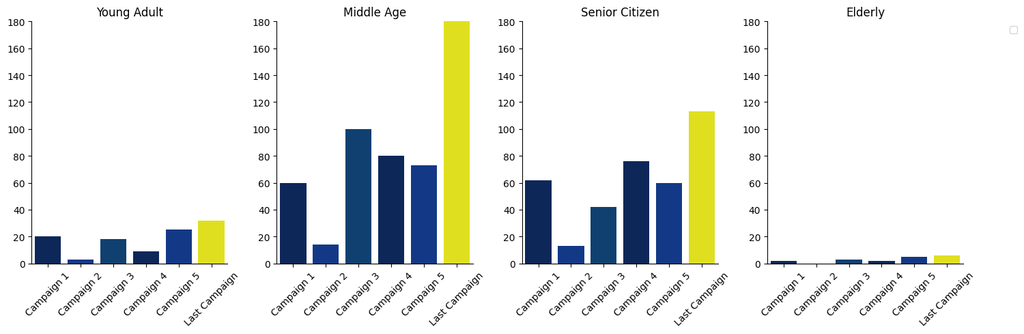

```python
# Plotting charts for other campaign acceptances for comparison and detecting patterns (if any)

data=[YoungAdult,MiddleAge,SeniorCitizen,Elderly]
titles=['Young Adult','Middle Age','Senior Citizen','Elderly']
colors = ['#002366', '#003399', '#004080','#002366', '#003399', '#FFFF00']

fig, axes = plt.subplots(nrows=1, ncols=4, figsize=(15,5))
for i, col in enumerate(titles):
        plot=sns.barplot(data=data[i],x='Campaign', y='No. of Customers',  ax=axes[i], palette=colors)
#         if i<4: axes[i].legend_.remove()
        plt.legend(loc='upper right', bbox_to_anchor=(1.3,1))
        sns.despine(top=True, right=True)
        axes[i].set_xlabel('' )
        axes[i].set_ylabel('')
        axes[i].set_title(titles[i])
        axes[i].set_xticklabels(axes[i].get_xticklabels(), rotation=45)
        plot.set_ylim(0, 180)


plt.tight_layout()
plt.show()
```

*Insights:*

- `Young Adult`: Young Adults have shown acceptance across all campaign; acceptance rate is mostly consistent across campaigns
- `Middle Age`: This group of customers accept offers across all campaingns; with acceptance rate doubling in the last campaign
- `Senior Citizen`: These customers have good acceptance across campaigns; acceptance rate is higher in the last campaign
- `Elderly`: The Elderly have low acceptance rate across campaigns; this can be attributed to the fact that number of purchases by the Elderly is also low.

#### Which Country has the greatest number of customers who accepted the last campaign?

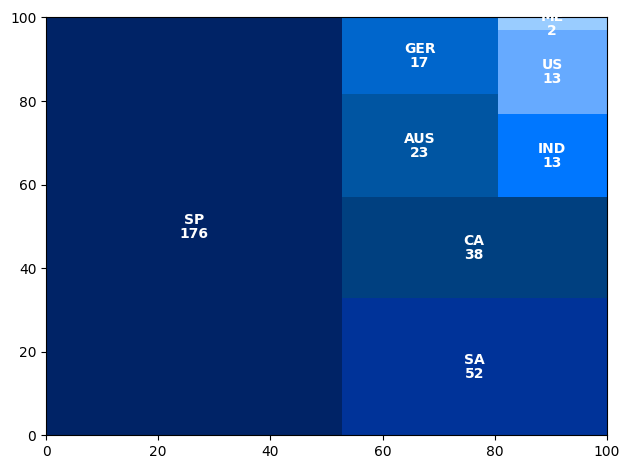

```python
# Create dataset of customers who accepted the last campaign
marketing_data_last_campaign = pd.DataFrame(marketing_data_no_outliers[marketing_data_no_outliers['Response']==1].groupby('Country').count()['Age'].sort_values(ascending=False).reset_index().rename(columns={'Age':'Number of Customers'}))


# Creating a treemap to compare the number of customers between Countries

colors = ['#002366', '#003399', '#004080', '#0055a2','#0066cc', '#0077ff', '#66aaff', '#99ccff']  # Custom colors

squarify.plot(sizes = marketing_data_last_campaign['Number of Customers'],
              label = marketing_data_last_campaign['Country'],
              value = marketing_data_last_campaign['Number of Customers'],
              color=colors,
              text_kwargs={'color':'white', 'fontweight':'bold'},

      )

plt.tight_layout()
plt.show()
```

*Insights*

- `Spain` has the greatest number of customers (176) who accepted the last campaign.

#### Do you see any pattern in the no. of children at home and total spend?

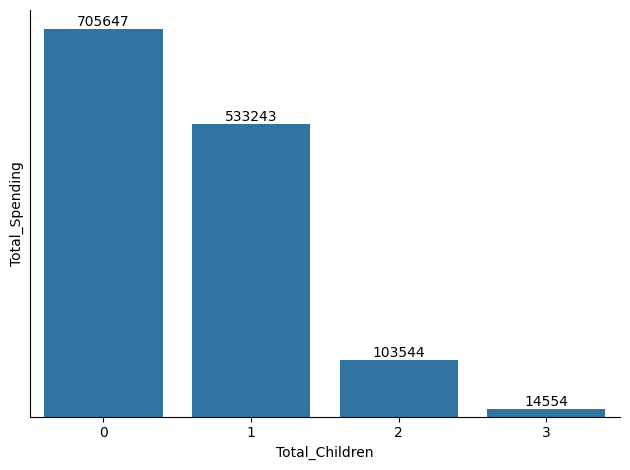

```python
# Create Total Spend data
TotalSpend = pd.DataFrame(marketing_data.groupby('Total_Children').sum()['Total_Spending'].reset_index())


# Plotting the graph

sns.barplot(data=TotalSpend, x='Total_Children', y='Total_Spending' )

for index, value in enumerate(TotalSpend['Total_Spending']):
    plt.annotate(str(value), xy=(index, value), ha='center', va='bottom')

sns.despine(right=True, top=True)
plt.yticks([])
plt.tight_layout()
plt.show()
```

*Insights*

- There seems to be a `negative correlation` between no. of children at home and total spend - as the number of children increases, we see total spending decreases.

#### Education background of the customers who complained in the last 2 years.

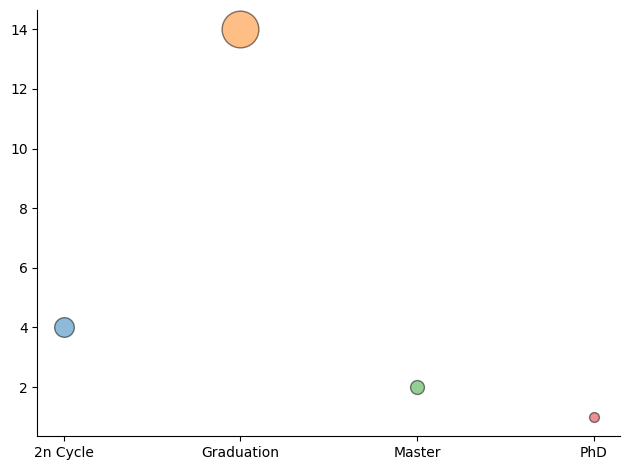

```python
# Create Complain data for last 2 years

Complain_data = pd.DataFrame(marketing_data_no_outliers[marketing_data_no_outliers['Complain']==1].groupby('Education').count()['Complain'].reset_index())

_2nCycle = Complain_data.iloc[0:1]
Graduation = Complain_data.iloc[1:2]
Master = Complain_data.iloc[2:3]
PhD = Complain_data.iloc[3:]


# Create the chart

plt.scatter(data=_2nCycle, x='Education', y='Complain', s=_2nCycle['Complain']*50,
            alpha=0.5, edgecolor='black', cmap='viridis')
plt.scatter(data=Graduation, x='Education', y='Complain', s=Graduation['Complain']*50,
            alpha=0.5, edgecolor='black', cmap='viridis')
plt.scatter(data=Master, x='Education', y='Complain', s=Master['Complain']*50,
            alpha=0.5, edgecolor='black', cmap='viridis')
plt.scatter(data=PhD, x='Education', y='Complain', s=PhD['Complain']*50,
            alpha=0.5, edgecolor='black', cmap='viridis')

sns.despine(right=True, top=True)
plt.tight_layout()
```

*Insights*

- Majority of complaints (14) in the last 2 years were made customers who have completed their `Graduation`.